# FigureYa143survCor_update

**Author(s)**: Xiaofan Lu  
**Reviewer(s)**: Ying Ge, Junyi Shen  
**Date**: 2025-11-21

## 1 Academic Citation

If you use this code in your work or research, we kindly request that you cite our publication:

Xiaofan Lu, et al. (2025). FigureYa: A Standardized Visualization Framework for Enhancing Biomedical Data Interpretation and Research Efficiency. iMetaMed. https://doi.org/10.1002/imm3.70005

## 2 需求描述 Requirement description

绘制较复杂的相关性图，包括计算每个表达值下的logrank score；以肠癌MSS和MSI样本为例。 Draw a more complex correlation graph, including calculating the logrank score for each expression value; take colorectal cancer MSS and MSI samples as an example.

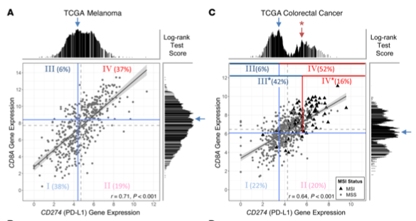

From https://www.jci.org/articles/view/127046

Figure 1. Comparison of TME stratification based on CD8A and CD274 gene expression between TCGA melanoma and CRC. Scatter plots of log2-transformed CD8A and CD274 **gene expression** values are shown (A and C) for melanoma (n = 459) and CRC (n = 599), respectively. A linear regression line is plotted with the **gray shaded region showing the 95% confidence interval**. Pearson’s correlation coefficient r and P values are given at the bottom. **MSI (black triangles) and MSS (gray circles) statuses** are labeled for CRC samples. **Median values of CD8A and CD274 expression are indicated with dashed gray lines**. log-rank statistics were applied to identify the optimal cut-off for transforming the continuous variable of gene expression into categorical high- and low-expression groups in a survfit model. The test score at each candidate cut-off across the log-transformed gene expression values was plotted. **The highest test score (indicated with a blue arrow) was applied for best separating patients into 4 different risk groups (using solid blue lines; named groups I to IV)**. To compare risk groups between melanoma and CRC, we also applied a secondary peak of test scores (red arrow with an asterisk, which revealed a reverse pattern of survival in CRC as shown in Supplemental Figure 2) for CD274 stratification (indicated with a solid red line instead of a blue line; named groups I, II, III* and IV*). Each stratified risk group is labeled with its population fraction in percentages.

**Statistics**. CD8A and PD-L1 gene expression were chosen for investigation from the 20 correlated genes (Bedognetti et al.; ref. 12). We used **log-rank statistics** to identify the **optimal expression cut-off** for each gene with regard to the associated hazard of death or relapse events in a survfit model (63), using the cutp function of the **R package survMisc** (version 0.5.5; https://CRAN.R-project.org/package=survMisc). The cut-off with the **highest log-rank test score was selected for best separating patients into high- and low-expression groups with different risks**. Upon observing a bimodal distribution of marginal log-rank statistics for CRC, but not melanoma, CD274 expression value at a secondary mode was used to identify a second set of high-risk subjects.

**图的解读：**

A和C图展示了CD8A（杀伤性T细胞）和CD274（PD-L1）在黑色素瘤和结直肠癌中的表达水平。用一张图同时展示：

- 基因表达相关性（线性回归线和置信区间）：展示 CD274 (PD-L1) 和 CD8A 的表达相关性（Pearson 相关系数 r 和 P 值）。
- Log-rank 统计：找到基于生存的最佳表达 cut-off
- 风险分组及样本占比：基于 cut-off （由蓝色线划分）的四象限分组（I, II, III, IV），每个象限标注样本百分比
- MSI/MSS 状态分布

**Figure interpretation:** A and C figures show the expression levels of CD8A(killer T cell) and CD274(PD-L1) in melanoma and CRC.

- Gene expression correlation (linear regression line and confidence interval): show the expression correlation of CD274 (PD-L1) and CD8A (Pearson correlation coefficient r and P value)
- Log-rank statistics: find the optimal expression cut-off
- Risk grouping: four quadrants based on cut-off (divided by blue lines); I, II, III, IV), each quadrant labeled with sample percentage
- MSI/MSS status distribution

**免疫微环境特征与预后分析：** 通过 CD274 (PD-L1) 和 CD8A 基因表达的联合分析，评估肿瘤免疫微环境的特征，包括：

- **象限 I（左下）**：低 PD-L1、低 CD8+ T 细胞 - 免疫冷肿瘤，通常预后较差
- **象限 II（右下）**：高 PD-L1、低 CD8+ T 细胞 - 原发性免疫抑制，预后通常较差
- **象限 III（左上）**：低 PD-L1、高 CD8+ T 细胞 - 免疫活跃型，通常预后较好
- **象限 IV（右上）**：高 PD-L1、高 CD8+ T 细胞 - 适应性免疫抵抗，可能对免疫治疗敏感

**Immuno-environmental features and prognosis analysis:** Through the combined analysis of CD274 (PD-L1) and CD8A gene expression, the features of the tumor immune microenvironment are evaluated, including:

基于生存信息，通过log-rank statistics找到最佳分组cut-off。

用复杂相关性图同时展示基因表达相关性、MSI/MSS状态、最佳cut-off、分组等信息。

如果只想计算并展示相关性，画出类似的图，可参考FigureYa92immune_gene。

Use log-rank statistics based on survival information to find the best grouping cut-off.

Use complex correlation graphs to simultaneously display gene expression correlation, MSI/MSS status, best cut-off, grouping and other information.

If you only want to calculate and display the correlation and draw a similar graph, refer to FigureYa92immune_gene.

## 3 环境设置 Environment settings

```r
source("install_dependencies.R")
```

[output not shown]

```r
library(survival) # 计算生存分析 Calculate survival analysis
library(survMisc) # 计算最佳分组cut-off Calculate best grouping cut-off
library(shape) # 画一个更漂亮的箭头 Draw a more beautiful arrow

Sys.setenv(LANGUAGE = "en") # Display English error message
options(stringsAsFactors = FALSE) # Disable conversion of chr to factor
```

## 4 输入文件 Input file

For Figure 1A of the reference paper, we need to download the data from the UCSC Xena browser.

Download TCGA Melanoma (SKCM) (17 datasets) data from UCSC Xena browser (https://xenabrowser.net/datapages/)

For Figure 1C of the reference paper, we need to download the data from the UCSC Xena browser.

Download TCGA Colorectal Cancer (COADREAD) (16 datasets) data from UCSC Xena browser (https://xenabrowser.net/datapages/)

```r
#cancer_type <- "SKCM" # Figure 1A
cancer_type <- "COADREAD" # Figure 1C

# 从Xena下载的HiSeqV2表达数据中提取CD274和CD8A的表达值
# Extract CD274 and CD8A expression values from HiSeqV2 expression data downloaded from Xena
hiseq_file <- paste0("TCGA.", cancer_type, ".sampleMap_HiSeqV2_PANCAN.gz")

# 读取HiSeqV2表达数据（基因行为行，样本为列）
# Read HiSeqV2 expression data (genes as rows, samples as columns)
hiseq_data <- read.delim(hiseq_file,
                         sep = "\t",
                         header = TRUE,
                         row.names = 1,
                         stringsAsFactors = FALSE,
                         check.names = FALSE)

# 提取CD274和CD8A的表达值
# Extract expression values for CD274 and CD8A
cd274_expr <- hiseq_data["CD274", , drop = FALSE]
cd8a_expr <- hiseq_data["CD8A", , drop = FALSE]

# 转置并合并为表达矩阵（样本为行，基因为列）
# Transpose and combine into expression matrix (samples as rows, genes as columns)
expr <- data.frame(
  CD274 = as.numeric(cd274_expr[1, ]),
  CD8A = as.numeric(cd8a_expr[1, ]),
  row.names = colnames(hiseq_data),
  stringsAsFactors = FALSE
)

cat("表达矩阵维度 / Expression matrix dimensions:", dim(expr), "\n")
```

```
## 表达矩阵维度 / Expression matrix dimensions: 434 2
```

```r
head(expr)
```

```
##                    CD274      CD8A
## TCGA-CA-5256-01 2.088657 -1.920048
## TCGA-AZ-6599-01 2.710757 -3.197848
## TCGA-AA-3655-01 3.891157 -2.580148
## TCGA-A6-6137-01 3.906257 -3.349348
## TCGA-CK-4952-01 3.696157 -5.029648
## TCGA-A6-5657-01 3.266357 -1.881648
```

```r
# 从Xena下载的生存数据中读取生存信息
# Read survival information from survival data downloaded from Xena
survival_file <- paste0("survival_", cancer_type, "_survival.txt")
surv <- read.delim(survival_file,
                   sep = "\t",
                   header = TRUE,
                   stringsAsFactors = FALSE,
                   check.names = FALSE)

# 设置行名为样本ID
# Set row names to sample ID
rownames(surv) <- surv$sample

# 只保留OS和OS.time列
# Keep only OS and OS.time columns
surv <- surv[, c("OS", "OS.time"), drop = FALSE]

cat("生存数据维度 / Survival data dimensions:", dim(surv), "\n")
```

```
## 生存数据维度 / Survival data dimensions: 728 2
```

```r
head(surv)
```

```
##                 OS OS.time
## TCGA-3L-AA1B-01  0     475
## TCGA-4N-A93T-01  0     146
## TCGA-4T-AA8H-01  0     385
## TCGA-5M-AAT4-01  1      49
## TCGA-5M-AAT6-01  1     290
## TCGA-5M-AATE-01  0    1200
```

```r
# 从Xena下载的临床数据中提取MSI信息（如果存在）
# Extract MSI information from clinical data downloaded from Xena (if available)
# 注意：SKCM（黑色素瘤）可能没有MSI信息，MSI主要是结直肠癌的特征
# Note: SKCM (melanoma) may not have MSI information, as MSI is mainly a feature of colorectal cancer
clinical_file <- paste0("TCGA.", cancer_type, ".sampleMap_", cancer_type, "_clinicalMatrix")

# 读取临床数据文件（TSV格式）
# Read clinical data file (TSV format)
clinical_data <- read.delim(clinical_file,
                            sep = "\t",
                            header = TRUE,
                            stringsAsFactors = FALSE,
                            check.names = FALSE)

# 第一列是样本ID
# First column is sample ID
sample_col <- colnames(clinical_data)[1]

# 查找MSI相关的列（优先使用MSI_updated_Oct62011）
# Find MSI-related columns (prefer MSI_updated_Oct62011)
# 注意：某些癌症类型（如黑色素瘤SKCM）可能没有MSI信息，这是正常的
# Note: Some cancer types (e.g., melanoma SKCM) may not have MSI information, which is normal
msi_cols <- grep("MSI|msi|microsatellite|instability", colnames(clinical_data), ignore.case = TRUE, value = TRUE)

if (length(msi_cols) == 0) {
  cat("未找到MSI相关的列。某些癌症类型（如黑色素瘤）可能没有MSI信息，将跳过MSI分析。\n")
  cat("No MSI-related columns found. Some cancer types (e.g., melanoma) may not have MSI information, will skip MSI analysis.\n")
  has_msi <- FALSE
} else {
  has_msi <- TRUE
}

if (has_msi) {
  # 合并多个MSI列以获取更完整的数据
  # Merge multiple MSI columns to get more complete data
  # 优先使用MSI_updated_Oct62011（包含MSS/MSI-L/MSI-H），如果为空则使用microsatellite_instability（YES/NO）
  # Prefer MSI_updated_Oct62011 (contains MSS/MSI-L/MSI-H), if empty use microsatellite_instability (YES/NO)

  msi_col1 <- NULL
  msi_col2 <- NULL

  if ("MSI_updated_Oct62011" %in% msi_cols) {
    msi_col1 <- "MSI_updated_Oct62011"
  }
  if ("microsatellite_instability" %in% msi_cols) {
    msi_col2 <- "microsatellite_instability"
  }

  if (is.null(msi_col1) && is.null(msi_col2)) {
    cat("未能找到可用的MSI列，将跳过MSI分析。\n")
    cat("No usable MSI columns found, will skip MSI analysis.\n")
    has_msi <- FALSE
  } else {
    # 合并MSI数据
    # Merge MSI data
    combined_msi <- rep(NA_character_, nrow(clinical_data))

    if (!is.null(msi_col1)) {
      msi1_values <- clinical_data[[msi_col1]]
      combined_msi <- msi1_values
      cat("使用MSI列1 / Using MSI column 1:", msi_col1, "\n")
    }

    if (!is.null(msi_col2)) {
      msi2_values <- clinical_data[[msi_col2]]
      # 如果MSI列1为空，使用MSI列2的值
      # If MSI column 1 is empty, use MSI column 2 values
      empty_idx <- is.na(combined_msi) | combined_msi == ""
      combined_msi[empty_idx] <- msi2_values[empty_idx]
      # 将YES/NO转换为MSI-H/MSS
      # Convert YES/NO to MSI-H/MSS
      combined_msi[combined_msi == "YES"] <- "MSI-H"
      combined_msi[combined_msi == "NO"] <- "MSS"
      if (any(empty_idx)) {
        cat("使用MSI列2补充缺失值 / Using MSI column 2 to fill missing values:", msi_col2, "\n")
      }
    }

    # 创建MSI结果数据框
    # Create MSI results data frame
    msi_results <- data.frame(
      sample = clinical_data[[sample_col]],
      MSI = combined_msi,
      stringsAsFactors = FALSE
    )

    # 设置行名为样本ID
    # Set row names to sample IDs
    rownames(msi_results) <- msi_results$sample

    # 检查MSI值的分布
    # Check MSI value distribution
    cat("MSI值分布 / MSI value distribution:\n")
    print(table(msi_results$MSI, useNA = "always"))

    # 存储MSI信息（可选，用于重复使用）
    # Store MSI information (optional, for reuse)
    save(msi_results, file = paste0("msi_results_", cancer_type, ".rda"))
    cat("MSI信息已保存到 / MSI information saved to: msi_results.rda\n")
  }
} else {
  # 没有MSI信息，创建空的msi_results数据框
  # No MSI information, create empty msi_results data frame
  msi_results <- data.frame(
    sample = clinical_data[[sample_col]],
    MSI = rep(NA_character_, nrow(clinical_data)),
    stringsAsFactors = FALSE
  )
  rownames(msi_results) <- msi_results$sample
  cat("未找到MSI信息，将不进行MSI相关分析。\n")
  cat("No MSI information found, will not perform MSI-related analysis.\n")
}
```

```
## 使用MSI列1 / Using MSI column 1: MSI_updated_Oct62011
## 使用MSI列2补充缺失值 / Using MSI column 2 to fill missing values: microsatellite_instability
## MSI值分布 / MSI value distribution:
##
##       MSI-H MSI-L   MSS  <NA>
##   350    48    38   300     0
## MSI信息已保存到 / MSI information saved to: msi_results.rda
```

挑选表达矩阵、生存信息和MSI信息的共有样本： Select common samples from expression matrix, survival information, and MSI information:

```r
# 先匹配expr和surv（使用所有共同样本，不限制于有MSI信息的样本）
# First match expr and surv (use all common samples, not limited to those with MSI information)
expr_surv_common <- intersect(rownames(expr), rownames(surv))
com_sam <- expr_surv_common

if (length(com_sam) == 0) {
  stop("无法找到共同样本。请检查样本ID格式或数据文件。\nUnable to find common samples. Please check sample ID formats or data files.")
}

cat("expr和surv共同样本数 / Common samples between expr and surv:", length(com_sam), "\n")
```

```
## expr和surv共同样本数 / Common samples between expr and surv: 430
```

```r
# 重新排序数据以匹配com_sam的顺序
# Reorder data to match com_sam order
expr <- expr[com_sam,, drop = FALSE]
surv <- surv[com_sam,, drop = FALSE]

# 匹配MSI数据（所有数据都使用TCGA-XX-XXXX-XX格式，直接匹配）
# Match MSI data (all data uses TCGA-XX-XXXX-XX format, match directly)
# 为所有共同样本创建MSI数据框（如果样本不在msi_results中，MSI值为NA）
# Create MSI data frame for all common samples (if sample is not in msi_results, MSI value is NA)
msi_results_matched <- data.frame(
  sample = com_sam,
  MSI = msi_results[com_sam, "MSI"],
  stringsAsFactors = FALSE,
  row.names = com_sam
)

# 将NA转换为空字符串以便后续处理
# Convert NA to empty string for subsequent processing
msi_results_matched$MSI[is.na(msi_results_matched$MSI)] <- ""

cat("匹配到MSI信息的样本数 / Samples with MSI information:", nrow(msi_results_matched), "\n")
```

```
## 匹配到MSI信息的样本数 / Samples with MSI information: 430
```

```r
cat("有MSI值的样本数 / Samples with MSI values:", sum(msi_results_matched$MSI != "", na.rm = TRUE), "\n")
```

```
## 有MSI值的样本数 / Samples with MSI values: 138
```

```r
# 查找MSS/MSI-L样本（微卫星稳定）
# Find MSS/MSI-L samples (microsatellite stable)
# 注意：数据中空字符串可能表示缺失MSI信息，通常默认为MSS/MSI-L
# Note: Empty strings in data may indicate missing MSI info, usually default to MSS/MSI-L
# 我们将空字符串、NA、以及明确标记为"MSS"/"MSI-L"/"NO"的都视为MSS/MSI-L
# We treat empty strings, NA, and explicitly marked "MSS"/"MSI-L"/"NO" as MSS/MSI-L
msi_msi_values_matched <- as.character(msi_results_matched$MSI)
msi_msi_values_matched[is.na(msi_msi_values_matched) | msi_msi_values_matched == ""] <- "NO"
mss.sam <- rownames(msi_results_matched[which(msi_msi_values_matched %in% c("MSS","MSI-L","NO")),])
# 查找MSI-H样本（微卫星高度不稳定）
# Find MSI-H samples (microsatellite instability-high)
msi.sam <- rownames(msi_results_matched[which(msi_msi_values_matched %in% c("MSI-H","YES")),])

cat("MSS样本数 / MSS sample count:", length(mss.sam), "\n")
```

```
## MSS样本数 / MSS sample count: 415
```

```r
cat("MSI-H样本数 / MSI-H sample count:", length(msi.sam), "\n")
```

```
## MSI-H样本数 / MSI-H sample count: 15
```

```r
# 对数转化表达谱（在检查缺失值之前）
# Log transform expression (before checking missing values)
# 注意：Xena HiSeqV2数据已经是log2(RSEM+1)格式，不需要再次转换
# Note: Xena HiSeqV2 data is already in log2(RSEM+1) format, no need to transform again
# 如果数据是原始计数或TPM值（数值范围较大，如>100），则需要log2转换
# If data is raw counts or TPM values (large value range, e.g., >100), log2 transformation is needed
if (max(expr, na.rm = TRUE) > 100) {
  # 数据是原始计数或TPM值，需要log2转换
  # Data is raw counts or TPM values, log2 transformation needed
  expr <- round(log2(expr + 1), 2)
  cat("已对表达谱进行log2转换 / Applied log2 transformation to expression profile\n")
} else {
  # 数据已经是log2转换后的值，直接使用
  # Data is already log2 transformed, use directly
  expr <- round(expr, 2)
  cat("表达谱已经是log2转换后的值，未进行额外转换 / Expression profile is already log2 transformed, no additional transformation\n")
}
```

```
## 表达谱已经是log2转换后的值，未进行额外转换 / Expression profile is already log2 transformed, no additional transformation
```

```r
# 删除缺失值
# Remove missing values
valid_samples <- rownames(surv)[!is.na(surv$OS.time) & !is.na(surv$OS) & !is.na(expr$CD274) & !is.na(expr$CD8A)]

if (length(valid_samples) == 0) {
  stop("没有有效样本（所有样本都包含缺失值）。请检查数据质量。\nNo valid samples (all samples contain missing values). Please check data quality.")
}

expr <- expr[valid_samples,]
surv <- surv[valid_samples,]

# 更新mss.sam和msi.sam以仅包含有效样本（如果存在MSI信息）
# Update mss.sam and msi.sam to only include valid samples (if MSI information exists)
if (exists("has_msi") && has_msi && sum(msi_results_matched$MSI != "", na.rm = TRUE) > 0) {
  mss.sam <- intersect(mss.sam, valid_samples)
  msi.sam <- intersect(msi.sam, valid_samples)
} else {
  # 没有MSI信息，设置为空
  # No MSI information, set to empty
  mss.sam <- character(0)
  msi.sam <- character(0)
  has_msi <- FALSE
}
```

## 5 计算logrank score和相关性 Calculate logrank score and correlation

```r
#-------------------#
# 计算logrank score #
# Calculate logrank score #
#-------------------#

exprsurv <- cbind.data.frame(surv,expr) # 新建包含表达和生存的数据框 # Create a new data frame containing expression and survival
exprsurv$sampleID <- rownames(exprsurv) # 生成样名 # Generate sample names

# CD274
cox.CD274 <- coxph(Surv(OS.time, OS) ~ CD274, data=exprsurv) # cox回归 # cox regression
logrank.CD274 <- as.data.frame(print(cutp(cox.CD274))) # cut连续变量产生logrank score # Cut continuous variables to generate
```

```
## $CD274
##      CD274           U           Q         p
##      <num>       <num>       <num>     <num>
##   1:  1.86 11.74361619 1.199811239 0.1123514
##   2:  1.87 11.51593302 1.176549509 0.1254764
##   3:  1.88 10.76705280 1.100038587 0.1776881
##   4:  1.76 10.70125403 1.093316117 0.1829941
##   5:  1.77 10.47357085 1.070054387 0.2023160
##  ---
## 298:  3.16  0.06040743 0.006171652 1.0000000
## 299:  2.92  0.06039340 0.006170219 1.0000000
## 300:  3.28  0.03771933 0.003853675 1.0000000
## 301:  8.50  0.00000000 0.000000000 1.0000000
## 302: -1.07  0.00000000 0.000000000 1.0000000
```

```r
colnames(logrank.CD274)[1] <- "CD274"
logrank.CD274 <- logrank.CD274[order(logrank.CD274$CD274),]
peak.CD274 <- logrank.CD274[which.min(logrank.CD274$CD274.p),1] # 得到p值最小(logrank score 峰值)下对应的表达值 # Get the expression value corresponding to the minimum p value
peak.CD274.score <- logrank.CD274[which.min(logrank.CD274$CD274.p),2] # 找到logrank score 峰值 # Find the logrank score peak value

# CD8A
cox.CD8A <- coxph(Surv(OS.time, OS) ~ CD8A, data=exprsurv)
logrank.CD8A <- as.data.frame(print(cutp(cox.CD8A)))
```

```
## $CD8A
##       CD8A          U           Q         p
##      <num>      <num>       <num>     <num>
##   1: -0.88 8.49104368 0.867505330 0.4391222
##   2: -0.91 8.45241356 0.863558603 0.4449579
##   3: -0.93 8.00973426 0.818331341 0.5146258
##   4: -1.06 7.91355528 0.808505014 0.5303688
##   5: -0.95 7.85661755 0.802687850 0.5397755
##  ---
## 311: -2.44 0.10318825 0.010542444 1.0000000
## 312:  0.36 0.06395616 0.006534215 1.0000000
## 313: -2.46 0.02937687 0.003001350 1.0000000
## 314: -4.10 0.01474337 0.001506287 1.0000000
## 315: -9.25 0.00000000 0.000000000 1.0000000
```

```r
colnames(logrank.CD8A)[1] <- "CD8A"
logrank.CD8A <- logrank.CD8A[order(logrank.CD8A$CD8A),]
peak.CD8A <- logrank.CD8A[which.min(logrank.CD8A$CD8A.p),1]
peak.CD8A.score <- logrank.CD8A[which.min(logrank.CD8A$CD8A.p),2]

# 计算各区域的样本 (注意边际上的样本重复问题)
# Calculate the samples in each region (note the problem of sample duplication on the margin)
lefttop <- expr[which(expr$CD274 < peak.CD274 & expr$CD8A > peak.CD8A),]
leftbottom <- expr[which(expr$CD274 <= peak.CD274 & expr$CD8A <= peak.CD8A),]
righttop <- expr[which(expr$CD274 >= peak.CD274 & expr$CD8A >= peak.CD8A),]
rightbottom <- expr[which(expr$CD274 > peak.CD274 & expr$CD8A < peak.CD8A),]

lefttop.pct <- paste0("III (",round(nrow(lefttop)/nrow(expr),2)*100,"%)")
leftbottom.pct <- paste0("I (",round(nrow(leftbottom)/nrow(expr),2)*100,"%)")
righttop.pct <- paste0("IV (",round(nrow(righttop)/nrow(expr),2)*100,"%)")
rightbottom.pct <- paste0("II (",round(nrow(rightbottom)/nrow(expr),2)*100,"%)")

#------------#
# 计算相关性 #
# Calculate correlation #
#----------------#

cor <- cor.test(expr$CD274,expr$CD8A,method = "pearson") # 皮尔森相关性检验
r <- round(cor$estimate,2)
p <- ifelse(cor$p.value < 0.001," < 0.001", paste0(" = ",round(cor$p.value))) # p值显示为文本

#------------------------#
# 计算线性回归以及置信域 #
# Calculate linear regression and confidence region #
#------------------------#
reg <- lm(CD8A~CD274,data=expr[order(expr$CD274),]) # 注意要按照x轴排序  # Note that the order should be sorted according to the x-axis
ci <- as.data.frame(predict(reg, newdata = expr[order(expr$CD274),], interval = 'confidence')) # 计算置信域 # Calculate confidence region
```

## 6 开始画图 Start drawing

```r
# 设置颜色
# Set color
blue <- "#4F81BD"
red <- "#E53435"
lblue <- "#5bc0eb"
dblue <- "#1d00ff"
pink <- "#FF7FBF"

# 计算边界
# Calculate the boundary
ylim <- range(expr$CD8A) # 计算y轴边界 # Calculate the y-axis boundary
xlim <- range(expr$CD274) # 计算x轴边界 # Calculate the x-axis boundary

# 生成包含癌症类型的PDF文件名
# Generate PDF filename with cancer type
pdf_filename <- paste0("complex correlation with logrank score_", cancer_type, ".pdf")

# 保存pdf图像 # Save pdf image
pdf(pdf_filename, width = 6, height = 6)

# 设置画面布局，相同数字代表同一区块，数字越多代表该区块所占面积越大
# Set the screen layout, the same number represents the same block, the more numbers represent the larger area of the block
layout(matrix(c(1,1,1,1,2,
                3,3,3,3,4,
                3,3,3,3,4,
                3,3,3,3,4,
                3,3,3,3,4),
              byrow = T,nrow = 5))

#--------------------------------------------#
# 画布区域1：添加x轴相关的logrank test score #
# Canvas area 1: Add x-axis related logrank test score #
#--------------------------------------------#

par(bty="n", mgp = c(2,0.5,0), mar = c(0.6,4.1,2.1,0),tcl=-.25,xpd = T) # 注意mar参数要和其他区域匹配，分别显示图像为下，左，上，右预留的位置；xpd允许箭头超出图像范围
# Note that the mar parameter must match other regions, and the image is displayed as the reserved position for the bottom, left, top, and right respectively; xpd allows the arrow to exceed the image range
plot(NULL, NULL,
     xlim = xlim,ylim = c(0,max(logrank.CD274$CD274.U) + 5), # y轴额外空余一些距离放箭头
     xaxt = "n",yaxt = "n",ann=FALSE) # 不显示坐标轴

# 这里不能使用barplot原因在于x轴的间隔并不固定，其实barplot本身本身是rect函数的一种wrapper，所以这里用rect函数绘制条形图
# The reason why barplot cannot be used here is that the interval of the x-axis is not fixed. In fact, barplot itself is a wrapper of the rect function, so the rect function is used here to draw a bar chart
rect(xleft=logrank.CD274[order(logrank.CD274$CD274),"CD274"]-0.01,
     ybottom=0,
     xright=logrank.CD274[order(logrank.CD274$CD274),"CD274"]+0.01,
     ytop=logrank.CD274[order(logrank.CD274$CD274),"CD274.U"],col = "black")

# 在peak处添加箭头
# Add arrows at peak
Arrows(peak.CD274,peak.CD274.score + 5,
       peak.CD274,peak.CD274.score + 3,
       arr.length = 0.2,
       lwd = 2,col = blue,arr.type = "triangle")

#------------------------#
# 画布区域2：填充空白画布#
# Canvas area 2: Fill the blank canvas#
#------------------------#

par(bty="n", mgp = c(2,0.5,0), mar = c(4.1,4.1,0,0),tcl=-.25)
plot(0,0,col = "white",xaxt = "n",yaxt = "n",xlab = "",ylab = "")

#----------------------#
# 画布区域3：相关性主图#
# Canvas area 3: Correlation main graph#
#----------------------#

par(bty="o", mgp = c(2,0.5,0), mar = c(4.1,4.1,0,0),tcl = -.25,font.axis = 2,las = 1) # 注意坐标轴刻度均水平 # Note that the axis scale is horizontal
par(xpd=F)

# 绘制所有样本
# Draw all samples
all_samples <- rownames(expr)

# 检查是否有MSI信息
# Check if MSI information exists
if (exists("has_msi") && has_msi && length(msi.sam) > 0) {
  # 有MSI信息，按MSI状态绘制
  # Has MSI information, draw by MSI status
  samples_without_msi <- setdiff(all_samples, c(mss.sam, msi.sam))

  # 如果没有MSI信息的样本存在，先绘制它们
  # If samples without MSI information exist, draw them first
  if (length(samples_without_msi) > 0) {
    plot(expr[samples_without_msi,"CD274"], expr[samples_without_msi,"CD8A"],ylim = ylim,xlim = xlim,
         xlab = expression(italic(CD274)~"(PD-L1) Gene Expression"), # 注意斜体 # Note the italics
         ylab = expression(italic(CD8A)~" Gene Expression"),main = "", # 注意斜体 # Note the italics
         cex.lab = 1.8, # 坐标轴文字大小 # Axis text size
         cex.axis = 1.4, # 坐标轴刻度大小 # Axis scale size
         col="grey80",
         cex = 0.8,
         type = "p",pch = 19)
    # 然后添加MSS样本（覆盖在上面）
    # Then add MSS samples (on top)
    if (length(mss.sam) > 0) {
      points(expr[mss.sam,"CD274"], expr[mss.sam,"CD8A"],
             col="grey40",
             cex = 1.2,
             pch = 19) # 圆形为MSS # Circle is MSS
    }
  } else {
    # 如果所有样本都有MSI信息，直接绘制MSS样本
    # If all samples have MSI information, directly draw MSS samples
    if (length(mss.sam) > 0) {
      plot(expr[mss.sam,"CD274"], expr[mss.sam,"CD8A"],ylim = ylim,xlim = xlim,
           xlab = expression(italic(CD274)~"(PD-L1) Gene Expression"), # 注意斜体 # Note the italics
           ylab = expression(italic(CD8A)~" Gene Expression"),main = "", # 注意斜体 # Note the italics
           cex.lab = 1.8, # 坐标轴文字大小 # Axis text size
           cex.axis = 1.4, # 坐标轴刻度大小 # Axis scale size
           col="grey40",
           cex = 1.2,
           type = "p",pch = 19) # 圆形为MSS # Circle is MSS
    }
  }

  # 添加MSI样本 # Add MSI samples
  if (length(msi.sam) > 0) {
    points(expr[msi.sam,"CD274"], expr[msi.sam,"CD8A"],
           col="black",
           cex = 2, # 三角形稍大 # The triangle is slightly larger
           pch = 17) # 三角形为MSI # The triangle is MSI
  }
} else {
  # 没有MSI信息，绘制所有样本为灰色点
  # No MSI information, draw all samples as gray points
  plot(expr[all_samples,"CD274"], expr[all_samples,"CD8A"],ylim = ylim,xlim = xlim,
       xlab = expression(italic(CD274)~"(PD-L1) Gene Expression"), # 注意斜体 # Note the italics
       ylab = expression(italic(CD8A)~" Gene Expression"),main = "", # 注意斜体 # Note the italics
       cex.lab = 1.8, # 坐标轴文字大小 # Axis text size
       cex.axis = 1.4, # 坐标轴刻度大小 # Axis scale size
       col="grey40",
       cex = 1.2,
       type = "p",pch = 19)
}

# 添加中位数 # Add median
abline(h = median(expr$CD8A),lty = 2,col = "grey60",lwd = 2)
abline(v = median(expr$CD274),lty = 2,col = "grey60",lwd = 2)

# 添加logrank peak对应的表达值
# Add the expression value
abline(v = peak.CD274,lty = 2,col = blue,lwd = 2)
abline(h = peak.CD8A,lty = 2,col = blue,lwd = 2)

# 添加相关性
# 添加回归线 (由于例文并未布满整个画布，所以这里不使用abline)
# Add correlation
# Add regression line (since the example does not fill the entire canvas, abline is not used here)
lines(x = xlim,y = xlim*reg$coefficients[2] + reg$coefficients[1], lwd = 2)

# 添加置信带
# Add confidence band
polygon(round(c(sort(expr$CD274),rev(sort(expr$CD274))),2),
        round(c(ci$lwr,rev(ci$upr)),2),
        col=ggplot2::alpha("grey70",0.6),
        border=NA)

# 添加相关性文本
# Add correlation text
text(2,0,adj = 0,bquote(~italic(r)~" = "~.(r)~", "~italic(P)~.(p)),cex = 1.6) # 注意斜体

# 添加样本百分比（基于实际数据范围动态计算位置）
# Add sample percentage (calculate position dynamically based on actual data range)
# 计算每个象限的中心位置
# Calculate the center position of each quadrant
xmin <- par("usr")[1]
xmax <- par("usr")[2]
ymin <- par("usr")[3]
ymax <- par("usr")[4]

# 象限I (leftbottom): 左下 - CD274 < peak, CD8A < peak
# Quadrant I (leftbottom): bottom left - CD274 < peak, CD8A < peak
text(xmin + (peak.CD274 - xmin) / 2, ymin + (peak.CD8A - ymin) / 2,
     bquote(bold(.(leftbottom.pct))), cex = 1.6, col = lblue)

# 象限II (rightbottom): 右下 - CD274 >= peak, CD8A < peak
# Quadrant II (rightbottom): bottom right - CD274 >= peak, CD8A < peak
text(peak.CD274 + (xmax - peak.CD274) / 2, ymin + (peak.CD8A - ymin) / 2,
     bquote(bold(.(rightbottom.pct))), cex = 1.6, col = pink)

# 象限III (lefttop): 左上 - CD274 < peak, CD8A >= peak
# Quadrant III (lefttop): top left - CD274 < peak, CD8A >= peak
text(xmin + (peak.CD274 - xmin) / 2, peak.CD8A + (ymax - peak.CD8A) / 2,
     bquote(bold(.(lefttop.pct))), cex = 1.6, col = dblue)

# 象限IV (righttop): 右上 - CD274 >= peak, CD8A >= peak
# Quadrant IV (righttop): top right - CD274 >= peak, CD8A >= peak
text(peak.CD274 + (xmax - peak.CD274) / 2, peak.CD8A + (ymax - peak.CD8A) / 2,
     bquote(bold(.(righttop.pct))), cex = 1.6, col = red)

# 添加图例
# 确定图片边界（如果之前没有定义，在这里定义）
# Add legend
# Determine the image boundary (if not already defined, define here)
if (!exists("xmin") || !exists("xmax") || !exists("ymin") || !exists("ymax")) {
  xmin <- par("usr")[1]
  xmax <- par("usr")[2]
  ymin <- par("usr")[3]
  ymax <- par("usr")[4]
}

# 如果有MSI信息，添加图例
# If MSI information exists, add legend
if (exists("has_msi") && has_msi && length(msi.sam) > 0) {
  # 确定图例大小
  # Determine the legend size
  lgd <- legend(x = mean(c(xmin,xmax)), y =  mean(c(ymin,ymax)),
                legend = c("MSI","MSS"),
                col = c("black","grey40"),
                pch = c(17,19),
                cex = 1.5,
                border = NA,
                title = expression(bold("MSI Status")),
                y.intersp = 1, x.intersp = 0.8,
                bty = "o",
                plot = F)

  # 定位图例悬浮在右下角（不同于bottomright）
  # Position the legend to float in the lower right corner (different from bottomright)
  legend(x = xmax - lgd$rect$w - 0.1, y =  ymin + lgd$rect$h + 0.1,
         legend = c("MSI","MSS"),
         col = c("black","grey40"),
         pch = c(17,19),
         cex = 1.5,
         border = NA,
         title = expression(bold("MSI Status")),
         y.intersp = 1, x.intersp = 0.8,
         bty = "o",
         plot = T)
}

#--------------------------------------------#
# 画布区域4：添加y轴相关的logrank test score #
# Canvas area 4: Add y-axis related logrank test score #
#--------------------------------------------#

par(bty="n", mgp = c(2,0.5,0), mar = c(4.1,0.6,0,2.1),tcl=-.25,xpd = T)
plot(NULL, NULL,
     xlim = c(0,max(logrank.CD8A$CD8A.U) + 5),ylim = ylim,
     xaxt = "n",yaxt = "n",ann=FALSE)

rect(xleft=0,
     ybottom=logrank.CD8A[order(logrank.CD8A$CD8A),"CD8A"]-0.01,
     xright=logrank.CD8A[order(logrank.CD8A$CD8A),"CD8A.U"],
     ytop=logrank.CD8A[order(logrank.CD8A$CD8A),"CD8A"]+0.01,col = "black")

Arrows(peak.CD8A.score + 5,peak.CD8A,
       peak.CD8A.score + 3,peak.CD8A,
       arr.length = 0.2,
       lwd = 2,col = blue,arr.type = "triangle")

# 关闭图形句柄
#Close graphics handle
invisible(dev.off())
```

[figure not shown]

Complex correlation with logrank score